# Lithics3D: A 3D analysis toolbox

Cornel M. Pop

2019-04-20

## Introduction

The purpose of the `Lithics3D` package is to provide a flexible R toolbox for working with 3D scans of archaeological lithics. The included functions are meant to be as modular as possible so that they may be combined in different ways to achieve a wide range of goals. This vignette demonstrates some potential uses of the `Lithics3D` library, which, at the moment, provides the following core components (for details please see the help pages):

- Functions to solve basic geometric problems such as line/line intersections or projecting points onto a plane
- Functions for orienting 3D scans
- Functions for sectioning 3D scans into meaningful components (e.g. ventral surfaces of flakes)
- Functions for measuring edge angles and other object attributes (e.g. volume)
- Three scans (and landmarks) used for test purposes

## About this document

Currently this is but a quick and dirty way of showcasing some of the functionality provided by this early version of the `Lithics3D` package. Hopefully it will be considerably more polished in the near future.

## Feature tours:

### 1. Measuring edge angles on a flake

Automatic angle measurements can be made along an artifact’s edge using the `edgeAngles` function and some landmarks (can be as few as two!) to define the edge. The following demonstrates how this may be accomplished using one of the 3D scans and landmark sets included in the package.

First, let’s load the data. We will use demoFlake1 here and we will use the first three included landmarks to define the edge we’re interested in:

```r
library(Lithics3D)
library(rgl)

data(demoFlake1)
lms = demoFlake1$lms[c(1:3),]

shade3d(demoFlake1$mesh, color="green")
points3d(lms, color="red", size=10)
```

The landmarks we picked to identify an edge don’t do a very good job of describing said edge. If we wanted to measure edge angles at 30 locations along this edge we would use the `pathResample` function to identify 30 equidistant points along the path, as shown below, but with so few landmarks we would be sampling points along two lines, which don’t even run along the surface of the flake:

```r
#edge.curve = pathResample(as.matrix(lms), 30, method="npts")
#points3d(edge.curve, color="blue", size=6)
lines3d(lms, color="blue", lwd=3)
```

This obviously does not work, because these resampled points do not follow the actual edge of the object. What we really want to do is to use the available landmarks to trace the actual edge of the object in 3D space. This can be accomplished using the `sPathConnect` connect function to trace the shortest path between the given landmarks on the surface of the flake and following ridges along the way. This function returns the IDs of the mesh vertices rather than actual coordinates, so an intermediary step is required. Let’s try again:

```r
edge.curve.ids = sPathConnect(lms, demoFlake1$mesh, path.choice="ridges")
edge.curve.path = t(demoFlake1$mesh$vb)[edge.curve.ids,1:3]
lines3d(edge.curve.path, color="blue", size=6, lwd=4) # Let's see the actual path:
edge.curve = pathResample(edge.curve.path, 30, method="npts")
points3d(edge.curve, color="purple", size=10)
```

That certainly looks better! So, now we have sampling locations for edge angles, and all that’s left to do is to actually measure them using the high-level `edgeAngles` function, at a distance of 3mm:

```r
res = edgeAngles(demoFlake1$mesh, edge.curve, 3)
```

Done! But how? Let’s see by plotting:

```r
rgl.close()
points3d(edge.curve, color="purple", size=10)
for(i in 1:length(res)){
  lines3d(res[[i]]$inters.pts, lwd=3)
   ang.l = rbind(res[[i]]$inters.pts[1,],
               edge.curve[i+1,],
               res[[i]]$inters.pts[2,])
  lines3d(ang.l, color="blue", lwd=1)
}
```

As you notice, angles were not measured at the first and last point along the edge curve, because at the ends of the curve it is impossible to determine where the measurements should be performed.

### 2. Isolating the ventral surface and taking a closer look:

3D scans can be segmented into multiple components with the `mesh_segment_by_path` function and a set of landmarks defining a closed path to slice the mesh with. Here we will use a set of landmarks set around the perimeter of a test flake scan (demoFlake2) to isolate the ventral surface of the latter, orienting it so that it’s aligned with the XY plane, and examining the thickness/size of the bulb of percussion:

First, let’s load and see what the data looks like:

```r
data(demoFlake2)
shade3d(demoFlake2$mesh, color="green")
points3d(demoFlake2$lms, color="red", size=10)
```

Now, let’s split the flake connecting the available landmarks by following surface ridges:

```r
library(Morpho)
rgl.close()
m.seg = mesh_segment_by_path(demoFlake2$mesh, demoFlake2$lms)
shade3d(m.seg[[1]], color="green")
shade3d(m.seg[[2]], color="blue")
```

Done! But how? The `mesh_segment_by_path` function will first connect the landmarks using the `sPathConnect` function internally, and then it will use that path to section the mesh. Let’s plot that path using the underlying function:

```r
res = sPathConnect(demoFlake2$lms, demoFlake2$mesh, path.choice="ridges")
res = c(res, sPathConnect(demoFlake2$lms[c(nrow(demoFlake2$lms), 1), ],
                          demoFlake2$mesh, path.choice="ridges"))
lines3d(t(demoFlake2$mesh$vb)[res, ], color="yellow", lwd=6)
```

Now we can take a closer look at the isolated ventral surface, but it makes sense to orient it first so that we can plot it in 2D as well. The surface can be oriented in many different ways, but here we will use the `mesh.orient_by_contour_pca` function with landmarks along the edges of the flake (i.e. without the landmark located by the point of percussion).

Let’s take a look at the data:

```r
rgl.close()
new.path = sPathConnect(demoFlake2$lms[-nrow(demoFlake2$lms),],
                        demoFlake2$mesh, path.choice="ridges")
shade3d(m.seg[[2]], color="blue")
points3d(t(demoFlake2$mesh$vb)[new.path, 1:3], color="red", size=10)
```

Now we orient the isolated surface by performing a PCA on the path, resampling it at 100 equidistant points:

```r
library(geomorph)
```

```r
vent.o = mesh_orient_by_contour_pca(t(demoFlake2$mesh$vb)[new.path, 1:3],
                                    npts=100, m.seg[[2]])
```

Because this surface is now aligned with the XY plane, we can plot it in 2D! Let’s see what it looks like, using Z values to colour the surface by thickness, after ensuring the mean elevation or thickness (Z) value of the contour is zero.

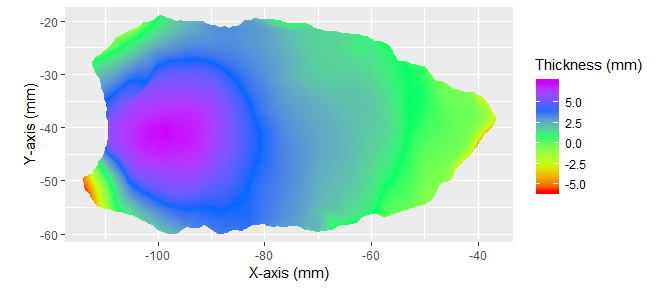

```r
library(ggplot2)
tp = data.frame(t(vent.o$mesh$vb)[,1:3])
tp[,3] = tp[,3] - mean(vent.o$contour.res[,3])
sp3<-ggplot(tp, aes(x=PC1, y=PC2, z=PC3, color=PC3)) + geom_point() + coord_fixed() + labs(col="Thickness (mm)")
sp3+scale_color_gradientn(colours=rainbow(5)) + xlab("X-axis (mm)") + ylab("Y-axis (mm)")
```

### 3. Map the thickness of a flake across its suface:

Thickness maps of 3D scans can be easily created and visualized using the `mesh_tmap` and `mesh_tmap_plot` functions, as demonstrated here with the included demoFlake2 data.

For thickness maps to be meaningful we must first orient the 3D scan in a meaningful way. What “meaningful” is will depend on the application. Here, we will orient the artifact using the `Morpho::pcAlign` function, although we could just as easily orient it as we did above with `mesh.orient_by_contour_pca`, with `alignAxis`, etc. `Morpho::pcAlign` provides a good way to automatically orient flat-ish and somewhat elongated objects such as blades, points, etc.

```r
mesh.rot = Morpho::pcAlign(demoFlake2$mesh)
```

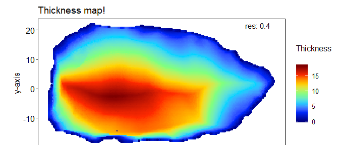

```r
library(ggplot2)

ld.cutoff = 0.003 # 0.3% of grid cells with less than 5 values.
base.res = 0.1 # Baseline resolution for thickness maps (0.2mm)
tmap <- mesh_tmap(mesh.rot, base.res, ld.cutoff)
g <- mesh_tmap_plot(tmap$tmap, 12, y.label="y-axis",
               x.label="x-axis", annot=paste("res:", tmap$res))
g + labs(title="Thickness map!")
```